# Lab: Análise de Componentes Principais

## Análise de Componentes Principais com base R

Neste lab, aplicaremos PCA nos dados `USArrests`, que faz parte do pacote base `R`.

As linhas da data frame contêm os 50 estados, em ordem alfabética:

```r
estados <- row.names(USArrests)
estados
```

```
##  [1] "Alabama"        "Alaska"         "Arizona"        "Arkansas"
##  [5] "California"     "Colorado"       "Connecticut"    "Delaware"
##  [9] "Florida"        "Georgia"        "Hawaii"         "Idaho"
## [13] "Illinois"       "Indiana"        "Iowa"           "Kansas"
## [17] "Kentucky"       "Louisiana"      "Maine"          "Maryland"
## [21] "Massachusetts"  "Michigan"       "Minnesota"      "Mississippi"
## [25] "Missouri"       "Montana"        "Nebraska"       "Nevada"
## [29] "New Hampshire"  "New Jersey"     "New Mexico"     "New York"
## [33] "North Carolina" "North Dakota"   "Ohio"           "Oklahoma"
## [37] "Oregon"         "Pennsylvania"   "Rhode Island"   "South Carolina"
## [41] "South Dakota"   "Tennessee"      "Texas"          "Utah"
## [45] "Vermont"        "Virginia"       "Washington"     "West Virginia"
## [49] "Wisconsin"      "Wyoming"
```

As colunas do conjunto de dados contêm as quatro variáveis:

```r
names(USArrests)
```

```
## [1] "Murder"   "Assault"  "UrbanPop" "Rape"
```

Inicialmente, examinamos brevemente os dados. Podemos notar que as variáveis têm médias muito diferentes.

```r
apply(USArrests, 2, mean)
```

```
##   Murder  Assault UrbanPop     Rape
##    7.788  170.760   65.540   21.232
```

Observe que a função `apply()` nos permite aplicar uma função — neste caso, a função `mean()` — a cada linha ou coluna do conjunto de dados.

O segundo argumento aqui indica se desejamos calcular a média das linhas, $1$, ou das colunas, $2$.

Vemos que há, em média, três vezes mais violações do que homicídios, e mais de oito vezes mais agressões do que violações.

Também podemos examinar as variância das quatro variáveis usando a função `apply()`.

```r
apply(USArrests, 2, var)
```

```
##     Murder    Assault   UrbanPop       Rape
##   18.97047 6945.16571  209.51878   87.72916
```

Não surpreende que a variabilidade é muito diferentes.

A variável `UrbanPop` mede a porcentagem da população de cada estado que vive em área urbana, que não é um número comparável ao número de estupros em cada estado por 100.000 indivíduos.

Se não padronizamos as variáveis antes de realizar a PCA, então a maioria dos componentes principais que observamos seriam impulsionados pela variável `Assault`, uma vez que ela tem de longe as maiores média e variância.

Assim, é importante padronizar as variáveis para que tenham média zero e desvio padrão um antes de realizar a PCA.

Agora realizamos a análise de componentes principais usando a função `prcomp()`, que é uma das várias funções em `R` que executam PCA:

```r
pr.out <- prcomp(USArrests, scale = TRUE)
```

Por padrão, a função `prcomp()` centraliza as variáveis para terem média zero. Usando a opção `scale = TRUE`, escalamos o variáveis para que tenham desvio padrão igual a um.

A saída de `prcomp()` contém uma série de quantidades úteis.

```r
names(pr.out)
```

```
## [1] "sdev"     "rotation" "center"   "scale"    "x"
```

Os componentes `center` e `scalce` correspondem às médias e desvios padrão das variáveis que foram utilizadas para escalonamento antes da implementação da PCA.

```r
pr.out$center
```

```
##   Murder  Assault UrbanPop     Rape
##    7.788  170.760   65.540   21.232
```

```r
pr.out$scale
```

```
##    Murder   Assault  UrbanPop      Rape
##  4.355510 83.337661 14.474763  9.366385
```

A matriz `rotation` contém as cargas dos componentes principais; cada coluna de `pr.out$rotation` contém o correspondente vetor de cargas do componente principal.

**Obs.** Esta função é chamada de matriz de rotação, porque quando multiplicamos a matriz $\bf X$ pela matriz `pr.out$rotation`, obtemos as coordenadas dos dados no sistema de coordenadas rotacionado. Essas coordenadas são os scores dos componentes principais.

```r
pr.out$rotation
```

```
##                 PC1        PC2        PC3         PC4
## Murder   -0.5358995 -0.4181809  0.3412327  0.64922780
## Assault  -0.5831836 -0.1879856  0.2681484 -0.74340748
## UrbanPop -0.2781909  0.8728062  0.3780158  0.13387773
## Rape     -0.5434321  0.1673186 -0.8177779  0.08902432
```

Vemos que existem quatro componentes principais distintos. Isso era esperado porque em geral, existem $\min(n-1,p)$ componentes principais informativos em um conjunto de dados com $n$ observações e $p$ variáveis.

Usando a função `prcomp()`, não precisamos multiplicar explicitamente os dados pelos vetores de cargas do componente principal para obter os vetores de scores do componente principal.

Em vez disso, a matriz `x` ($50 \times 4$) tem como colunas os vetores de scores dos componentes principais. Ou seja, a $k$ésima coluna de `x` é o $k$ésimo vetor de score do componente principal.

```r
dim(pr.out$x)
```

```
## [1] 50  4
```

Podemos representar graficamente os dois primeiros componentes principais da seguinte forma:

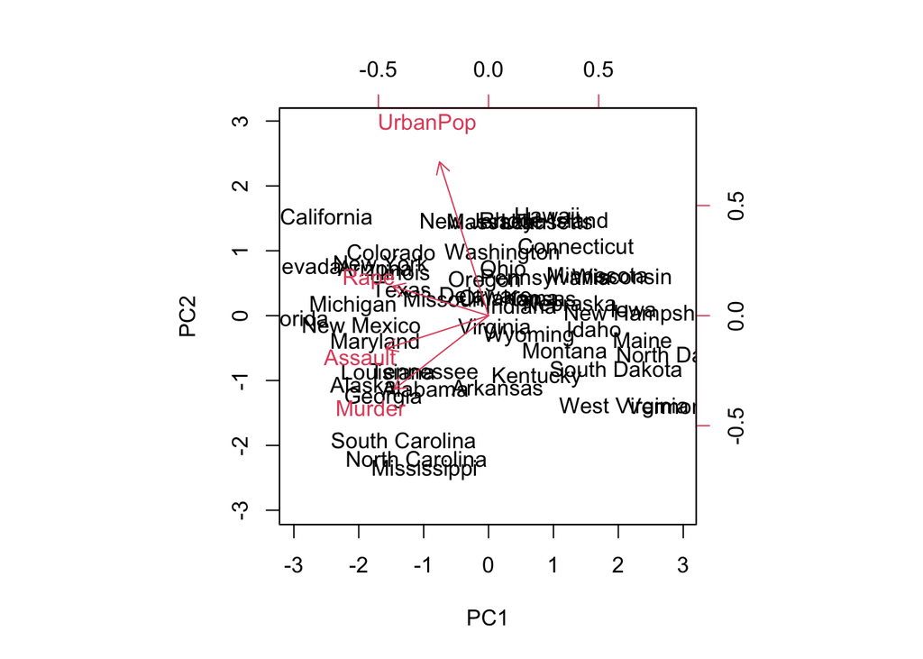

```r
biplot(pr.out, scale = 0)
```

The `scale = 0` argument to `biplot()` ensures that the arrows are scaled to represent the loadings; other values for `scale` give slightly different biplots with different interpretations.

O argumento `scale = 0` de `biplot()` garante que as setas sejam dimensionadas para representar as cargas; outros valores para `scale` fornecem biplots ligeiramente diferentes com interpretações diferentes.

Observe que esta figura é uma imagem espelhada da Fi. 2 dos slides.

Lembre-se de que os componentes principais só são únicos até uma mudança de sinal, portanto podemos reproduzir a Fig. 2 fazendo algumas pequenas alterações:

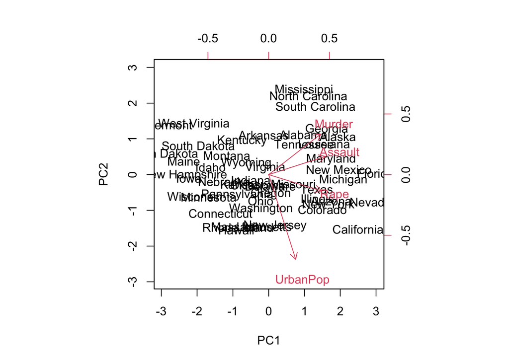

```r
pr.out$rotation = -pr.out$rotation
pr.out$x = -pr.out$x
biplot(pr.out, scale = 0)
```

A função `prcomp()` também gera o desvio padrão de cada componente principal.

Por exemplo, para os dados `USArrests`, podemos acessar esses desvios padrão fazendo:

```r
pr.out$sdev
```

```
## [1] 1.5748783 0.9948694 0.5971291 0.4164494
```

A variância explicada por cada componente principal é obtida elevando os desvios padrão ao quadrado:

```r
pr.var <- pr.out$sdev^2
pr.var
```

```
## [1] 2.4802416 0.9897652 0.3565632 0.1734301
```

Para calcular a proporção da variância explicada por cada componente principal, simplesmente dividimos a variância explicada por cada componente principal pela variância total explicada por todos os quatro componentes principais:

```r
pve <- pr.var / sum(pr.var)
pve
```

```
## [1] 0.62006039 0.24744129 0.08914080 0.04335752
```

Vemos que o primeiro componente principal explica $62,0\,\%$ da variação nos dados, o segundo componente principal explica $24,7\,\%$ da variação e assim por diante.

Podemos plotar a PVE explicada por cada componente, bem como a PVE acumulada, fazendo:

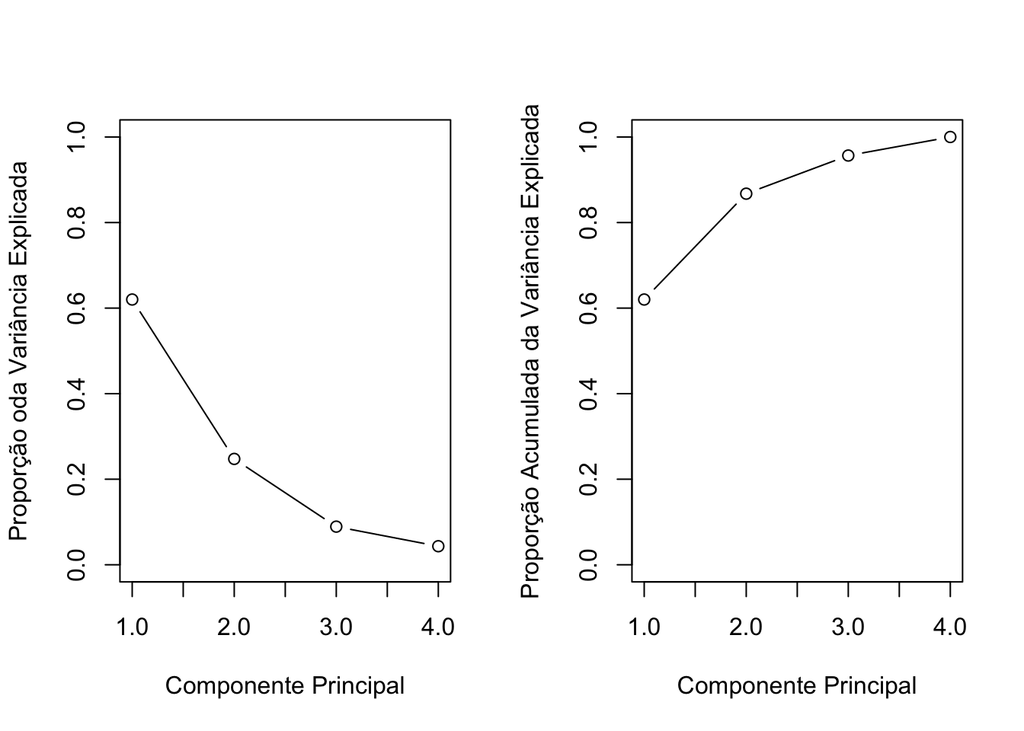

```r
par(mfrow = c(1, 2))

plot(pve,
     xlab = "Componente Principal",
     ylab = "Proporção oda Variância Explicada",
     ylim = c(0, 1),
     type = "b")

plot(cumsum(pve),
     xlab = "Componente Principal",
     ylab = "Proporção Acumulada da Variância Explicada",
     ylim = c(0, 1),
     type = "b")
```

Observe que a função `cumsum()` calcula a soma acumulada dos elementos de um vetor numérico. Por exemplo:

```r
a <- c(1, 2, 8, -3)
cumsum(a)
```

```
## [1]  1  3 11  8
```

## PCA via Decomposição SVD

Para ilustar a aplicação da decomposição SVD para os cálculos da análise de componentes principais, vamos transformar a data frame `USArrests` em uma matriz, após padronizar cada coluna para ter média zero e variância um.

```r
X <- data.matrix(scale(USArrests))
pcob <- prcomp(X)
summary(pcob)
```

```
## Importance of components:
##                           PC1    PC2     PC3     PC4
## Standard deviation     1.5749 0.9949 0.59713 0.41645
## Proportion of Variance 0.6201 0.2474 0.08914 0.04336
## Cumulative Proportion  0.6201 0.8675 0.95664 1.00000
```

Vemos que o primeiro componente principal explica $62\%$ da variabilidade dos dados.

Vimos nos slides que resolver o problema de otimização para auma matriz de dados centrada $\bf X$ é equivalente a computar os primeiros $M$ componentes principais dos dados.

A decomposição em valor singular (SVC) é um algoritmo geral para resolver a Eq. 12.6:

```r
sX <- svd(X)
names(sX)
```

```
## [1] "d" "u" "v"
```

```r
round(sX$v, 3)
```

```
##        [,1]   [,2]   [,3]   [,4]
## [1,] -0.536 -0.418  0.341  0.649
## [2,] -0.583 -0.188  0.268 -0.743
## [3,] -0.278  0.873  0.378  0.134
## [4,] -0.543  0.167 -0.818  0.089
```

A função `svd()` retorna os três componentes da decomposição: `u`, `d`, e `v`.

A matriz `v` é equivalente à matriz de cargas dos componentes principais (à exececão de uma inversão de sinal sem importância).

```r
pcob$rotation
```

```
##                 PC1        PC2        PC3         PC4
## Murder   -0.5358995 -0.4181809  0.3412327  0.64922780
## Assault  -0.5831836 -0.1879856  0.2681484 -0.74340748
## UrbanPop -0.2781909  0.8728062  0.3780158  0.13387773
## Rape     -0.5434321  0.1673186 -0.8177779  0.08902432
```

A matriz `u` é equivalente à matriz de scores *padronizados*, e os desvios padrão estão no vetor `d`.

Podemos recuperar os vetores de scores usando a saída de `svd()`. Eles são idênticos aos vetores de scores gerados pela função `prcomp()`.

```r
t(sX$d * t(sX$u))
```

```
##              [,1]        [,2]        [,3]         [,4]
##  [1,] -0.97566045 -1.12200121  0.43980366  0.154696581
##  [2,] -1.93053788 -1.06242692 -2.01950027 -0.434175454
##  [3,] -1.74544285  0.73845954 -0.05423025 -0.826264240
##  [4,]  0.13999894 -1.10854226 -0.11342217 -0.180973554
##  [5,] -2.49861285  1.52742672 -0.59254100 -0.338559240
##  [6,] -1.49934074  0.97762966 -1.08400162  0.001450164
##  [7,]  1.34499236  1.07798362  0.63679250 -0.117278736
##  [8,] -0.04722981  0.32208890  0.71141032 -0.873113315
##  [9,] -2.98275967 -0.03883425  0.57103206 -0.095317042
## [10,] -1.62280742 -1.26608838  0.33901818  1.065974459
## [11,]  0.90348448  1.55467609 -0.05027151  0.893733198
## [12,]  1.62331903 -0.20885253 -0.25719021 -0.494087852
## [13,] -1.36505197  0.67498834  0.67068647 -0.120794916
## [14,]  0.50038122  0.15003926 -0.22576277  0.420397595
```

[output cut: 36 more lines]

```r
pcob$x
```

```
##                        PC1         PC2         PC3          PC4
## Alabama        -0.97566045 -1.12200121  0.43980366  0.154696581
## Alaska         -1.93053788 -1.06242692 -2.01950027 -0.434175454
## Arizona        -1.74544285  0.73845954 -0.05423025 -0.826264240
## Arkansas        0.13999894 -1.10854226 -0.11342217 -0.180973554
## California     -2.49861285  1.52742672 -0.59254100 -0.338559240
## Colorado       -1.49934074  0.97762966 -1.08400162  0.001450164
## Connecticut     1.34499236  1.07798362  0.63679250 -0.117278736
## Delaware       -0.04722981  0.32208890  0.71141032 -0.873113315
## Florida        -2.98275967 -0.03883425  0.57103206 -0.095317042
## Georgia        -1.62280742 -1.26608838  0.33901818  1.065974459
## Hawaii          0.90348448  1.55467609 -0.05027151  0.893733198
## Idaho           1.62331903 -0.20885253 -0.25719021 -0.494087852
## Illinois       -1.36505197  0.67498834  0.67068647 -0.120794916
## Indiana         0.50038122  0.15003926 -0.22576277  0.420397595
## Iowa            2.23099579  0.10300828 -0.16291036  0.017379470
## Kansas          0.78887206  0.26744941 -0.02529648  0.204421034
## Kentucky        0.74331256 -0.94880748  0.02808429  0.663817237
## Louisiana      -1.54909076 -0.86230011  0.77560598  0.450157791
## Maine           2.37274014 -0.37260865  0.06502225 -0.327138529
## Maryland       -1.74564663 -0.42335704  0.15566968 -0.553450589
## Massachusetts   0.48128007  1.45967706  0.60337172 -0.177793902
## Michigan       -2.08725025  0.15383500 -0.38100046  0.101343128
## Minnesota       1.67566951  0.62590670 -0.15153200  0.066640316
## Mississippi    -0.98647919 -2.36973712  0.73336290  0.213342049
## Missouri       -0.68978426  0.26070794 -0.37365033  0.223554811
## Montana         1.17353751 -0.53147851 -0.24440796  0.122498555
## Nebraska        1.25291625  0.19200440 -0.17380930  0.015733156
## Nevada         -2.84550542  0.76780502 -1.15168793  0.311354436
## New Hampshire   2.35995585  0.01790055 -0.03648498 -0.032804291
## New Jersey     -0.17974128  1.43493745  0.75677041  0.240936580
## New Mexico     -1.96012351 -0.14141308 -0.18184598 -0.336121113
## New York       -1.66566662  0.81491072  0.63661186 -0.013348844
## North Carolina -1.11208808 -2.20561081  0.85489245 -0.944789648
## North Dakota    2.96215223 -0.59309738 -0.29824930 -0.251434626
## Ohio            0.22369436  0.73477837  0.03082616  0.469152817
## Oklahoma        0.30864928  0.28496113  0.01515592  0.010228476
## Oregon         -0.05852787  0.53596999 -0.93038718 -0.235390872
## Pennsylvania    0.87948680  0.56536050  0.39660218  0.355452378
## Rhode Island    0.85509072  1.47698328  1.35617705 -0.607402746
## South Carolina -1.30744986 -1.91397297  0.29751723 -0.130145378
## South Dakota    1.96779669 -0.81506822 -0.38538073 -0.108470512
## Tennessee      -0.98969377 -0.85160534 -0.18619262  0.646302674
## Texas          -1.34151838  0.40833518  0.48712332  0.636731051
## Utah            0.54503180  1.45671524 -0.29077592 -0.081486749
## Vermont         2.77325613 -1.38819435 -0.83280797 -0.143433697
## Virginia        0.09536670 -0.19772785 -0.01159482  0.209246429
## Washington      0.21472339  0.96037394 -0.61859067 -0.218628161
## West Virginia   2.08739306 -1.41052627 -0.10372163  0.130583080
## Wisconsin       2.05881199  0.60512507  0.13746933  0.182253407
## Wyoming         0.62310061 -0.31778662  0.23824049 -0.164976866
```